# Regression Models Class Project: Automatic vs Manual Transmission

Joselle Abagat

7/8/2018

## Topic:

You work for Motor Trend, a magazine about the automobile industry. Looking at a data set of a collection of cars, they are interested in exploring the relationship between a set of variables and miles per gallon (MPG) (outcome). They are particularly interested in the following two questions:

- “Is an automatic or manual transmission better for MPG”
- “Quantify the MPG difference between automatic and manual transmissions”

# **Analysis and Summary**

### Explore mtcars data set

The data frame mtcars consists of 32 observations on the following 11 variables: mpg, cyl, disp, hp, drat, wt, qsec, vs, am, gear, carb.

```r
str(mtcars)
```

```
## Classes 'data.table' and 'data.frame':   32 obs. of  11 variables:
##  $ mpg : num  21 21 22.8 21.4 18.7 18.1 14.3 24.4 22.8 19.2 ...
##  $ cyl : num  6 6 4 6 8 6 8 4 4 6 ...
##  $ disp: num  160 160 108 258 360 ...
##  $ hp  : num  110 110 93 110 175 105 245 62 95 123 ...
##  $ drat: num  3.9 3.9 3.85 3.08 3.15 2.76 3.21 3.69 3.92 3.92 ...
##  $ wt  : num  2.62 2.88 2.32 3.21 3.44 ...
##  $ qsec: num  16.5 17 18.6 19.4 17 ...
##  $ vs  : num  0 0 1 1 0 1 0 1 1 1 ...
##  $ am  : num  1 1 1 0 0 0 0 0 0 0 ...
##  $ gear: num  4 4 4 3 3 3 3 4 4 4 ...
##  $ carb: num  4 4 1 1 2 1 4 2 2 4 ...
##  - attr(*, ".internal.selfref")=<externalptr>
```

We want to explore the relationship between mpg and am (Transmission: 0 = automatic, 1 = manual). Based on the data summaries in Appendix A, mpg ranges from [10.4 to 24.4] with an average of 17.15 for automatic transmission while mpg ranges from [15 to 33.9] with an average of 24.39 for manual transmission. This can allow us to conclude that driving a manual transmission car leads to more miles per gallon. However, this does not take into account the effect of other variables such as the number of cylinders or car weight.

```r
cor(mtcars$mpg, mtcars[, -1])
```

```
##            cyl       disp         hp      drat         wt     qsec
## [1,] -0.852162 -0.8475514 -0.7761684 0.6811719 -0.8676594 0.418684
##             vs        am      gear       carb
## [1,] 0.6640389 0.5998324 0.4802848 -0.5509251
```

The correlation shows us that while mpg is positively impacted by transmission and number of gears, it is inversely impacted by the number of cylinders, horsepower, weight.

### Model Fitting and Selection

Analyzing different model fits, a general linear model did not apply since mpg can be represented as arange of values. Therefore, a binomial linear model could not be applied. It is also not a rate, therefore, a poisson linear model should not be applied. The most appropriate is a simple linear model via function lm(). Using step(), we can use a stepwise algorithm to choose the best model by AIC.

```r
mdlAll <- lm(mpg ~ ., mtcars)
mdlBest <- step(mdlAll, trace = 0)
```

Looking at the summaries of mdlAll and mdlBest in Appendix B, it can be seen that using all the predictors result in P-values > 0.05, which show that the relationships are not significant. Using the stepwise algorithm, the best model shows that wt (weight), qsec (1/4 mile time), and am (transmission) are the relevant predictors.

### Diagnostics

```r
anova(mdlBest)
```

```
## Analysis of Variance Table
##
## Response: mpg
##           Df Sum Sq Mean Sq  F value    Pr(>F)
## wt         1 847.73  847.73 140.2143 2.038e-12 ***
## qsec       1  82.86   82.86  13.7048 0.0009286 ***
## am         1  26.18   26.18   4.3298 0.0467155 *
## Residuals 28 169.29    6.05
## ---
## Signif. codes:  0 '***' 0.001 '**' 0.01 '*' 0.05 '.' 0.1 ' ' 1
```

To further optimize this model, let’s look at weight and quarter mile time as functions of transmission.

```r
mdlAM <- lm(mpg ~ factor(am):wt + factor(am):qsec, data = mtcars)
```

### Conclusion

As can be seen in Appendix C, the multiple R-squared is 89.5%, which means that the model has 89.5% variability.

In conclusion, manual transmission is better for MPG.

# **Appendices:**

### Appendix A: Explore cars

```r
summary(mtcars[am == 0]) # Transmission = Automatic
```

```
##       mpg             cyl             disp             hp
##  Min.   :10.40   Min.   :4.000   Min.   :120.1   Min.   : 62.0
##  1st Qu.:14.95   1st Qu.:6.000   1st Qu.:196.3   1st Qu.:116.5
##  Median :17.30   Median :8.000   Median :275.8   Median :175.0
##  Mean   :17.15   Mean   :6.947   Mean   :290.4   Mean   :160.3
##  3rd Qu.:19.20   3rd Qu.:8.000   3rd Qu.:360.0   3rd Qu.:192.5
##  Max.   :24.40   Max.   :8.000   Max.   :472.0   Max.   :245.0
##       drat             wt             qsec             vs
##  Min.   :2.760   Min.   :2.465   Min.   :15.41   Min.   :0.0000
##  1st Qu.:3.070   1st Qu.:3.438   1st Qu.:17.18   1st Qu.:0.0000
##  Median :3.150   Median :3.520   Median :17.82   Median :0.0000
##  Mean   :3.286   Mean   :3.769   Mean   :18.18   Mean   :0.3684
##  3rd Qu.:3.695   3rd Qu.:3.842   3rd Qu.:19.17   3rd Qu.:1.0000
##  Max.   :3.920   Max.   :5.424   Max.   :22.90   Max.   :1.0000
##        am         gear            carb
##  Min.   :0   Min.   :3.000   Min.   :1.000
##  1st Qu.:0   1st Qu.:3.000   1st Qu.:2.000
##  Median :0   Median :3.000   Median :3.000
##  Mean   :0   Mean   :3.211   Mean   :2.737
##  3rd Qu.:0   3rd Qu.:3.000   3rd Qu.:4.000
##  Max.   :0   Max.   :4.000   Max.   :4.000
```

```r
summary(mtcars[am == 1]) # Transmission = Manual
```

```
##       mpg             cyl             disp             hp
##  Min.   :15.00   Min.   :4.000   Min.   : 71.1   Min.   : 52.0
##  1st Qu.:21.00   1st Qu.:4.000   1st Qu.: 79.0   1st Qu.: 66.0
##  Median :22.80   Median :4.000   Median :120.3   Median :109.0
##  Mean   :24.39   Mean   :5.077   Mean   :143.5   Mean   :126.8
##  3rd Qu.:30.40   3rd Qu.:6.000   3rd Qu.:160.0   3rd Qu.:113.0
##  Max.   :33.90   Max.   :8.000   Max.   :351.0   Max.   :335.0
##       drat            wt             qsec             vs
##  Min.   :3.54   Min.   :1.513   Min.   :14.50   Min.   :0.0000
##  1st Qu.:3.85   1st Qu.:1.935   1st Qu.:16.46   1st Qu.:0.0000
##  Median :4.08   Median :2.320   Median :17.02   Median :1.0000
##  Mean   :4.05   Mean   :2.411   Mean   :17.36   Mean   :0.5385
##  3rd Qu.:4.22   3rd Qu.:2.780   3rd Qu.:18.61   3rd Qu.:1.0000
##  Max.   :4.93   Max.   :3.570   Max.   :19.90   Max.   :1.0000
##        am         gear            carb
##  Min.   :1   Min.   :4.000   Min.   :1.000
##  1st Qu.:1   1st Qu.:4.000   1st Qu.:1.000
##  Median :1   Median :4.000   Median :2.000
##  Mean   :1   Mean   :4.385   Mean   :2.923
##  3rd Qu.:1   3rd Qu.:5.000   3rd Qu.:4.000
##  Max.   :1   Max.   :5.000   Max.   :8.000
```

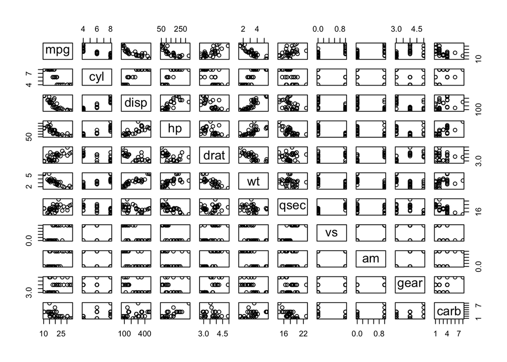

```r
pairs(mpg ~ ., data = mtcars)
```

### Appendix B: Model Fitting and Selection

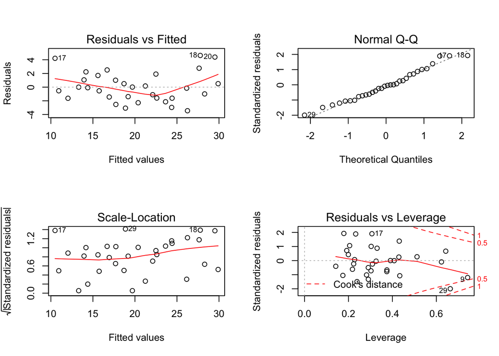

```r
par(mfrow = c(2,2))
plot(mdlAll)
```

```r
summary(mdlAll)
```

```
##
## Call:
## lm(formula = mpg ~ ., data = mtcars)
##
## Residuals:
##     Min      1Q  Median      3Q     Max
## -3.4506 -1.6044 -0.1196  1.2193  4.6271
##
## Coefficients:
##             Estimate Std. Error t value Pr(>|t|)
## (Intercept) 12.30337   18.71788   0.657   0.5181
## cyl         -0.11144    1.04502  -0.107   0.9161
## disp         0.01334    0.01786   0.747   0.4635
## hp          -0.02148    0.02177  -0.987   0.3350
## drat         0.78711    1.63537   0.481   0.6353
## wt          -3.71530    1.89441  -1.961   0.0633 .
## qsec         0.82104    0.73084   1.123   0.2739
## vs           0.31776    2.10451   0.151   0.8814
## am           2.52023    2.05665   1.225   0.2340
## gear         0.65541    1.49326   0.439   0.6652
## carb        -0.19942    0.82875  -0.241   0.8122
## ---
## Signif. codes:  0 '***' 0.001 '**' 0.01 '*' 0.05 '.' 0.1 ' ' 1
##
## Residual standard error: 2.65 on 21 degrees of freedom
## Multiple R-squared:  0.869,  Adjusted R-squared:  0.8066
## F-statistic: 13.93 on 10 and 21 DF,  p-value: 3.793e-07
```

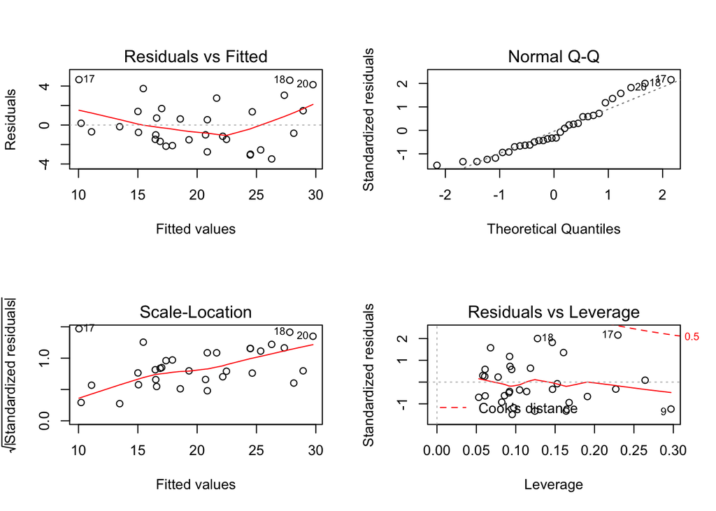

```r
plot(mdlBest)
```

```r
summary(mdlBest)
```

```
##
## Call:
## lm(formula = mpg ~ wt + qsec + am, data = mtcars)
##
## Residuals:
##     Min      1Q  Median      3Q     Max
## -3.4811 -1.5555 -0.7257  1.4110  4.6610
##
## Coefficients:
##             Estimate Std. Error t value Pr(>|t|)
## (Intercept)   9.6178     6.9596   1.382 0.177915
## wt           -3.9165     0.7112  -5.507 6.95e-06 ***
## qsec          1.2259     0.2887   4.247 0.000216 ***
## am            2.9358     1.4109   2.081 0.046716 *
## ---
## Signif. codes:  0 '***' 0.001 '**' 0.01 '*' 0.05 '.' 0.1 ' ' 1
##
## Residual standard error: 2.459 on 28 degrees of freedom
## Multiple R-squared:  0.8497, Adjusted R-squared:  0.8336
## F-statistic: 52.75 on 3 and 28 DF,  p-value: 1.21e-11
```

### Appendix C: Diagnostics

```r
summary(mdlAM)
```

```
##
## Call:
## lm(formula = mpg ~ factor(am):wt + factor(am):qsec, data = mtcars)
##
## Residuals:
##     Min      1Q  Median      3Q     Max
## -3.9361 -1.4017 -0.1551  1.2695  3.8862
##
## Coefficients:
##                  Estimate Std. Error t value Pr(>|t|)
## (Intercept)       13.9692     5.7756   2.419  0.02259 *
## factor(am)0:wt    -3.1759     0.6362  -4.992 3.11e-05 ***
## factor(am)1:wt    -6.0992     0.9685  -6.297 9.70e-07 ***
## factor(am)0:qsec   0.8338     0.2602   3.205  0.00346 **
## factor(am)1:qsec   1.4464     0.2692   5.373 1.12e-05 ***
## ---
## Signif. codes:  0 '***' 0.001 '**' 0.01 '*' 0.05 '.' 0.1 ' ' 1
##
## Residual standard error: 2.097 on 27 degrees of freedom
## Multiple R-squared:  0.8946, Adjusted R-squared:  0.879
## F-statistic: 57.28 on 4 and 27 DF,  p-value: 8.424e-13
```

```r
confint(mdlAM)
```

```
##                       2.5 %    97.5 %
## (Intercept)       2.1186308 25.819783
## factor(am)0:wt   -4.4813221 -1.870450
## factor(am)1:wt   -8.0864869 -4.111900
## factor(am)0:qsec  0.2999593  1.367612
## factor(am)1:qsec  0.8939972  1.998754
```

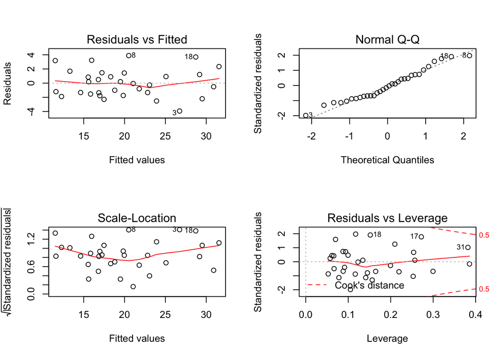

```r
par(mfrow = c(2,2))
plot(mdlAM)
```